# Business Analytics - Final Project

Critical Thinking Group 5

Arindam Barman

Mohamed Elmoudni

Shazia Khan

Kishore Prasad

# Overview

The data set contains approximately 41188 obs. of 21 variables.  
This dataset is based on “Bank Marketing” UCI dataset (please check the description at: http://archive.ics.uci.edu/ml/datasets/Bank+Marketing). The data is enriched by the addition of five new social and economic features/attributes (national wide indicators from a ~10M population country), published by the Banco de Portugal and publicly available at: https://www.bportugal.pt/estatisticasweb.\

The binary classification goal is to predict if the client will subscribe a bank term deposit (variable y).

# 1 Data Exploration Analysis

In section we will explore and gain some insights into the dataset by pursuing the below high level steps and inquiries:  
-Variable identification  
-Missing values and Unique Values

## 1.2 Missing values and Unique Values

# 2 Data Preparation

-Convert Binary to 0 and 1  
-Create dummy variables  
-Data Summary Analysis  
-Correlation of Variables with y

## 2.1 Convert Binary yes and no to 0 and 1

Now in order to prepare the data for modeling, we need to update Yes = 1 and No = 0.

## 2.5 # Outliers

## 2.6 Analysis the link function

## 2.7 Interpretation

### Analysis of the predictor variables:

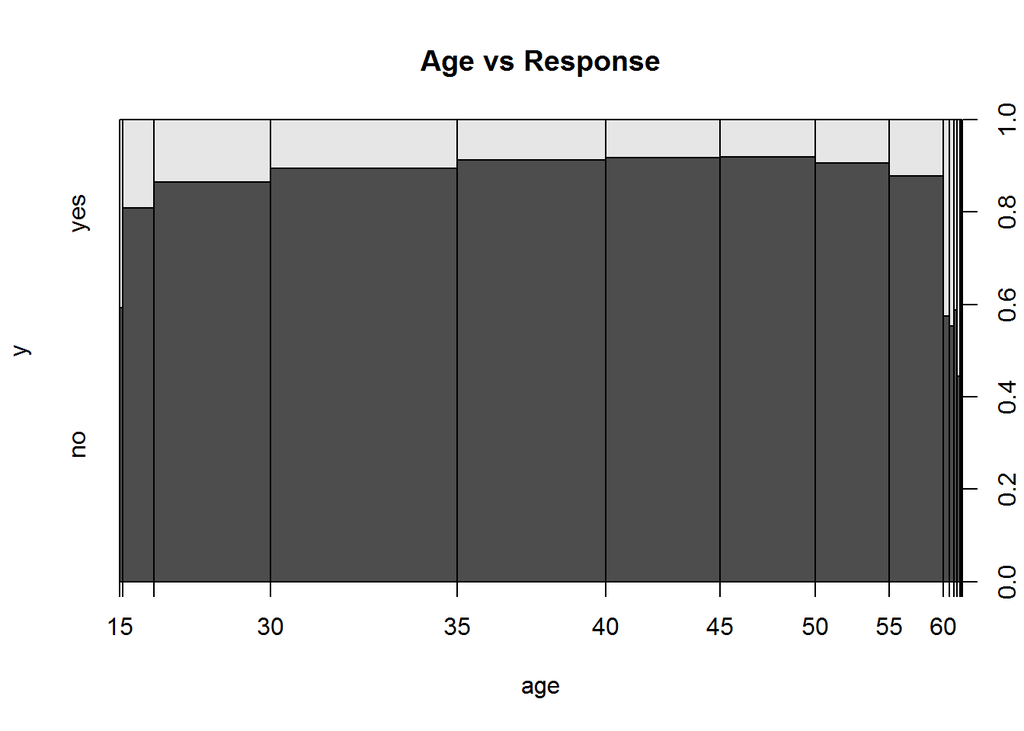

Analysis: from the chart above, it can be seen how the campaign response varies with different age group. It appears that better response was received from young age group between 15-30 and then age group above 60.

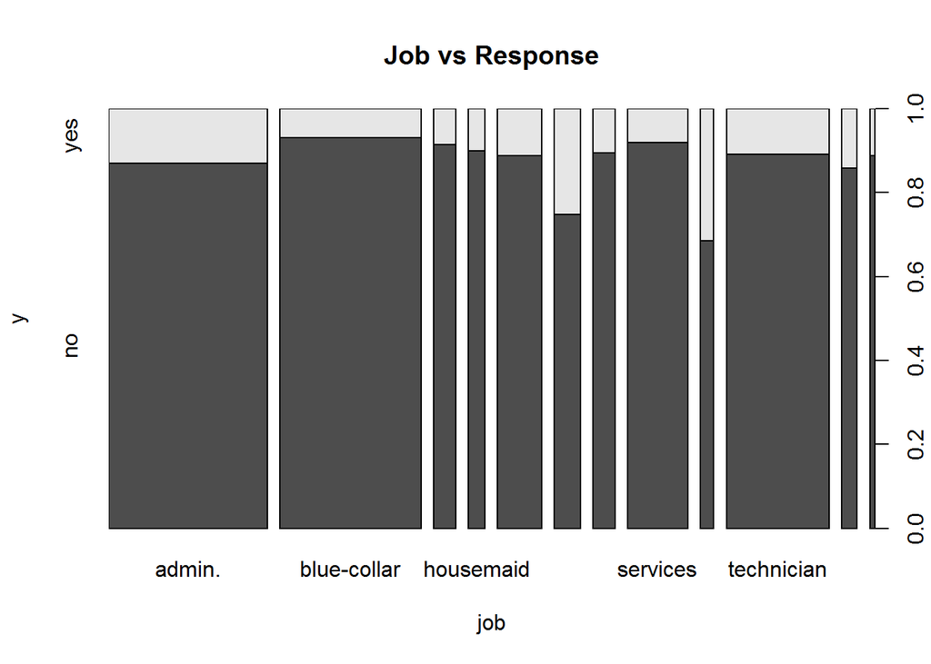

Analysis: from the chart above, it can be seen among student and retired personel proportion of positive response is higher though their propostion in overall population is low. Among other profession Admin looks ike having the higher total number of responses

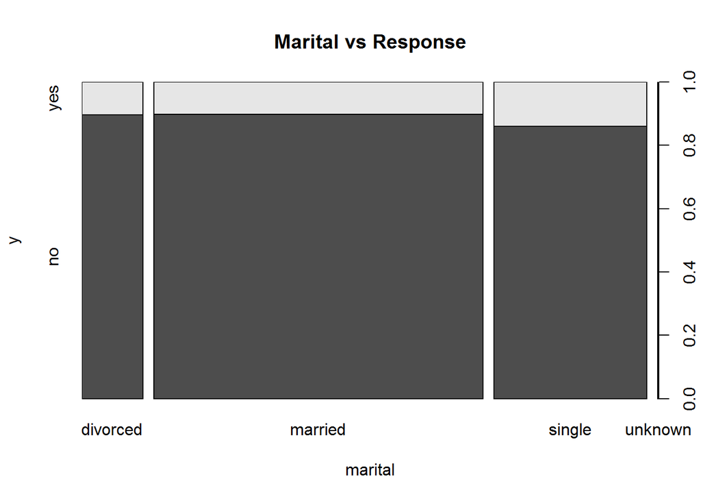

Responses from single status folks were relatively higher.

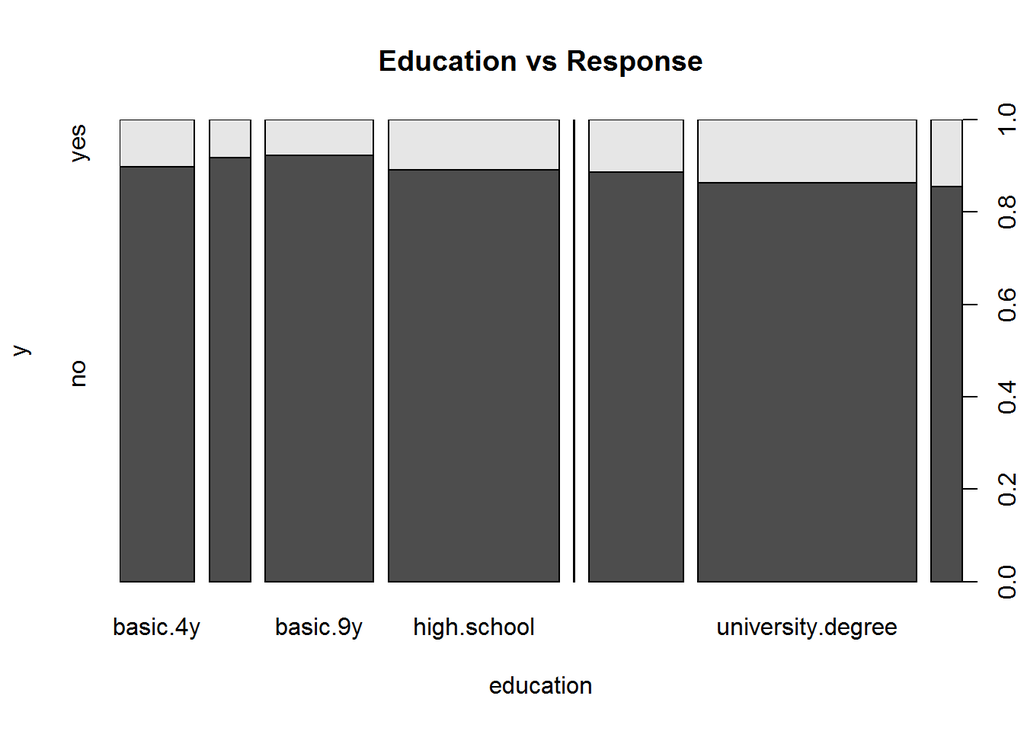

Responses from university educated person is relatively higher.

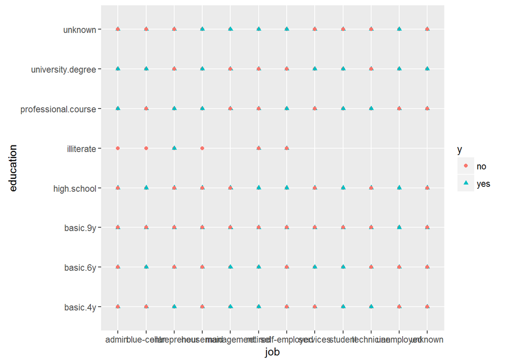

Above diagram shows interaction between variable Job and education with response variable

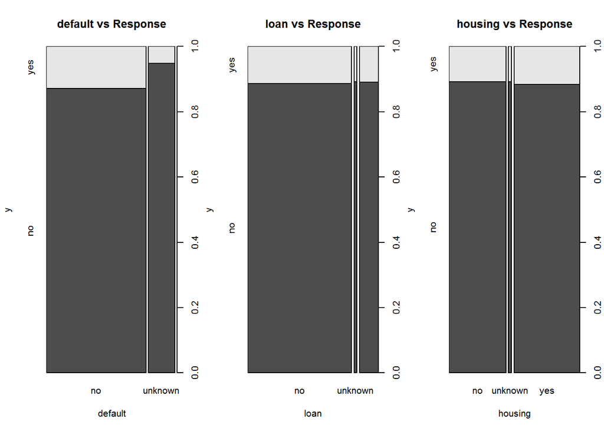

With loan and housing variable proportion of responses do not change as shwon from chart

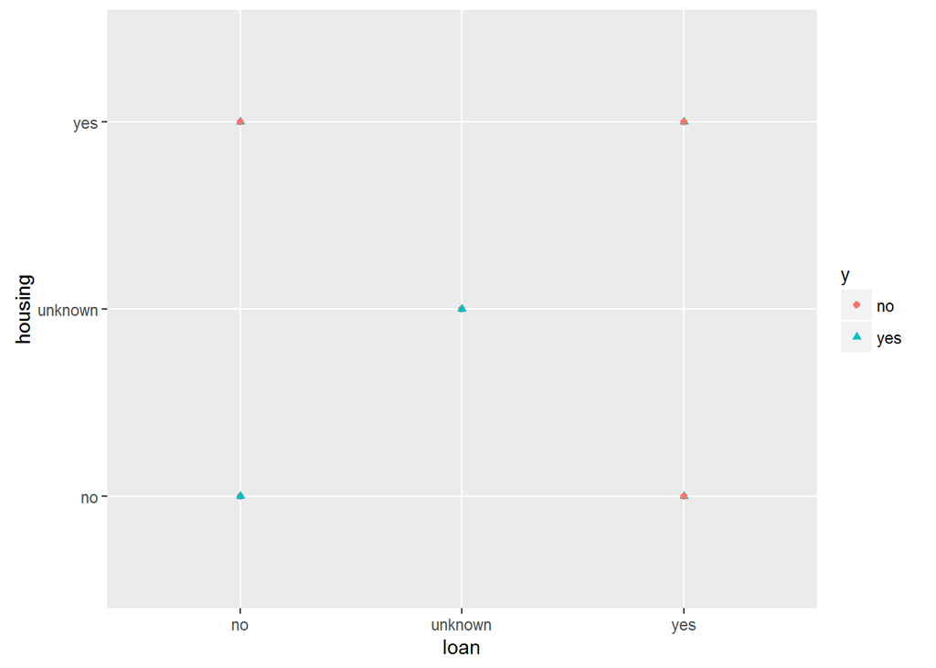

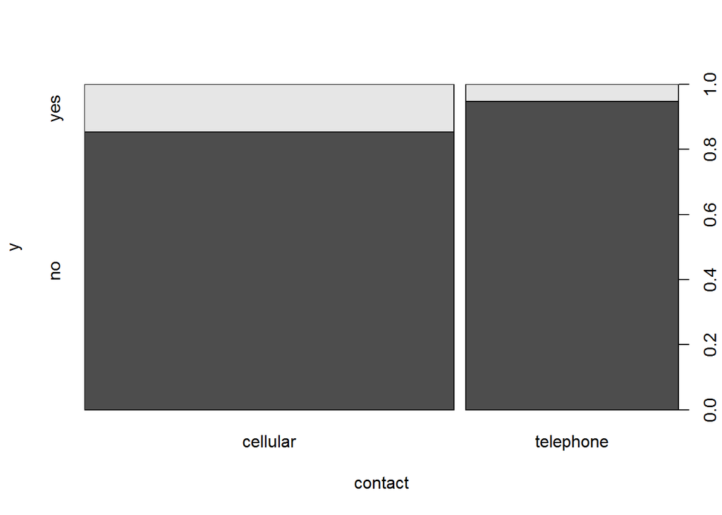

Responses from contact of type cellular is higher compare to other types

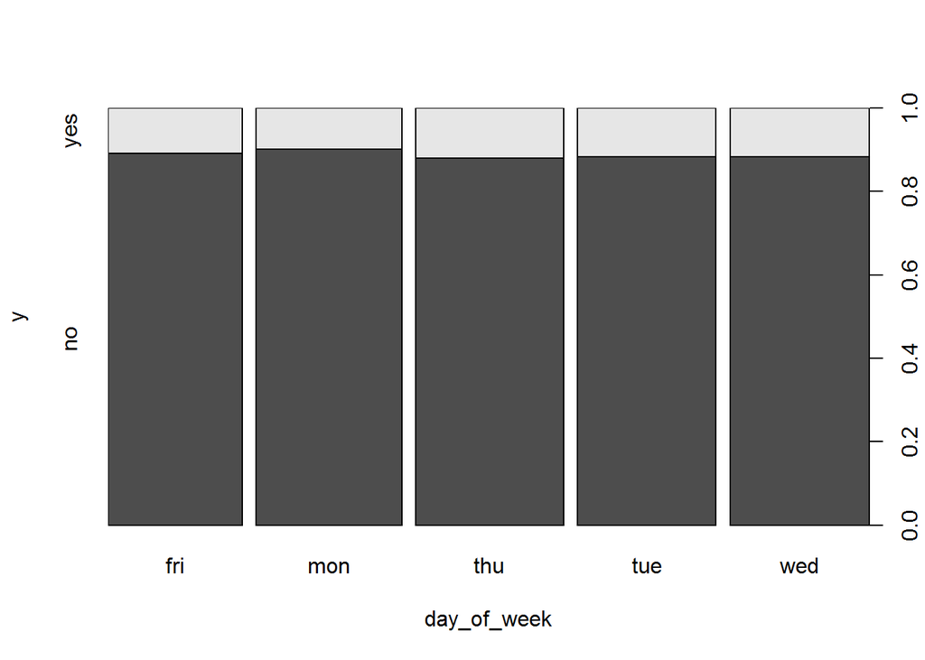

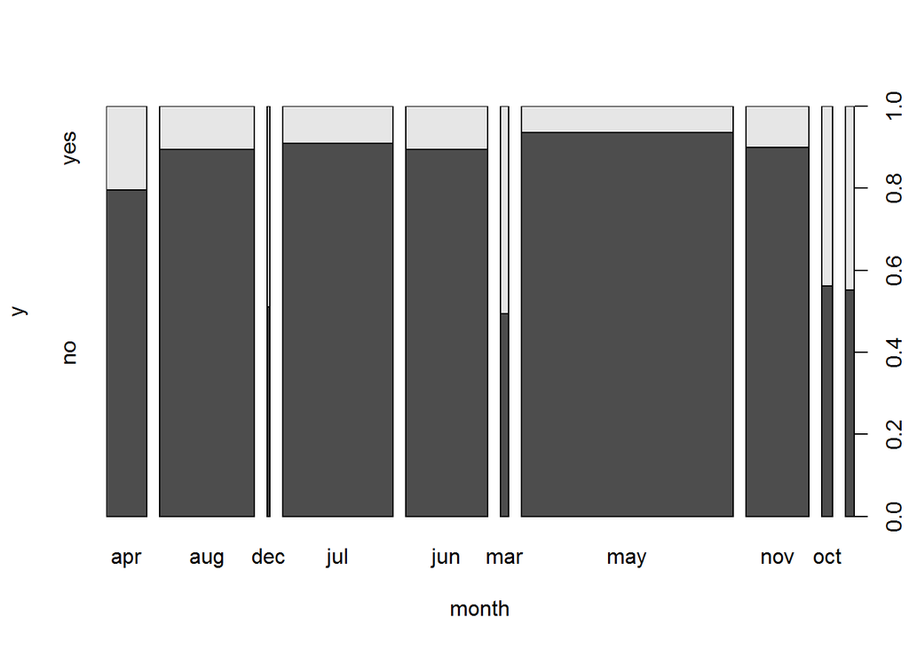

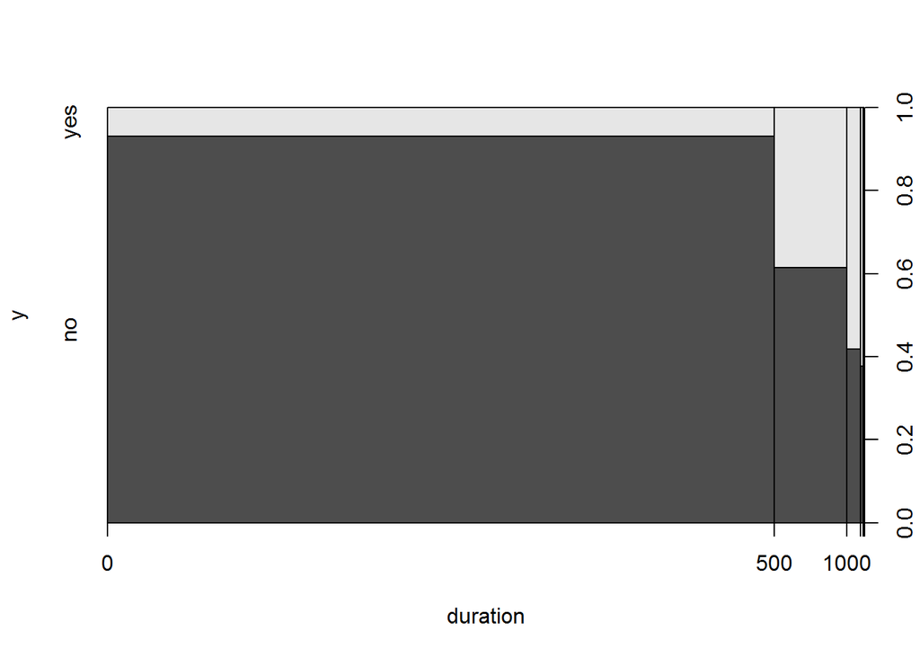

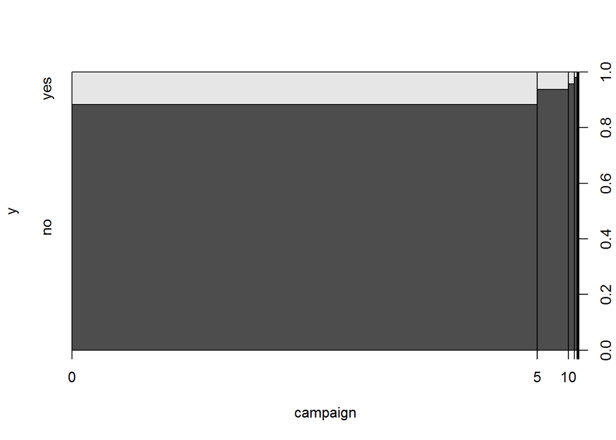

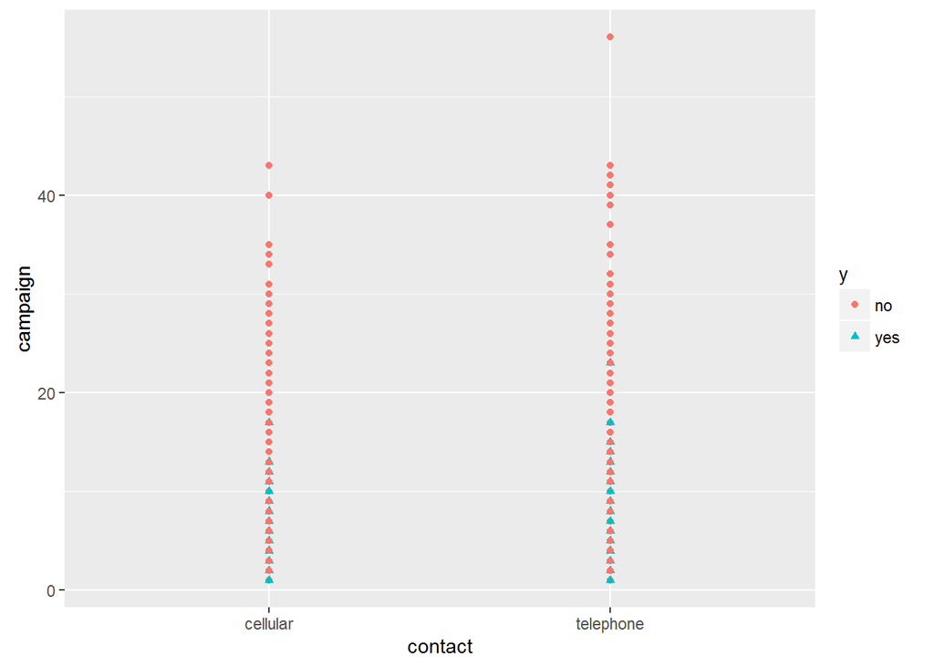

It can be seen higher number of interactions has reduced the number of positive responses.

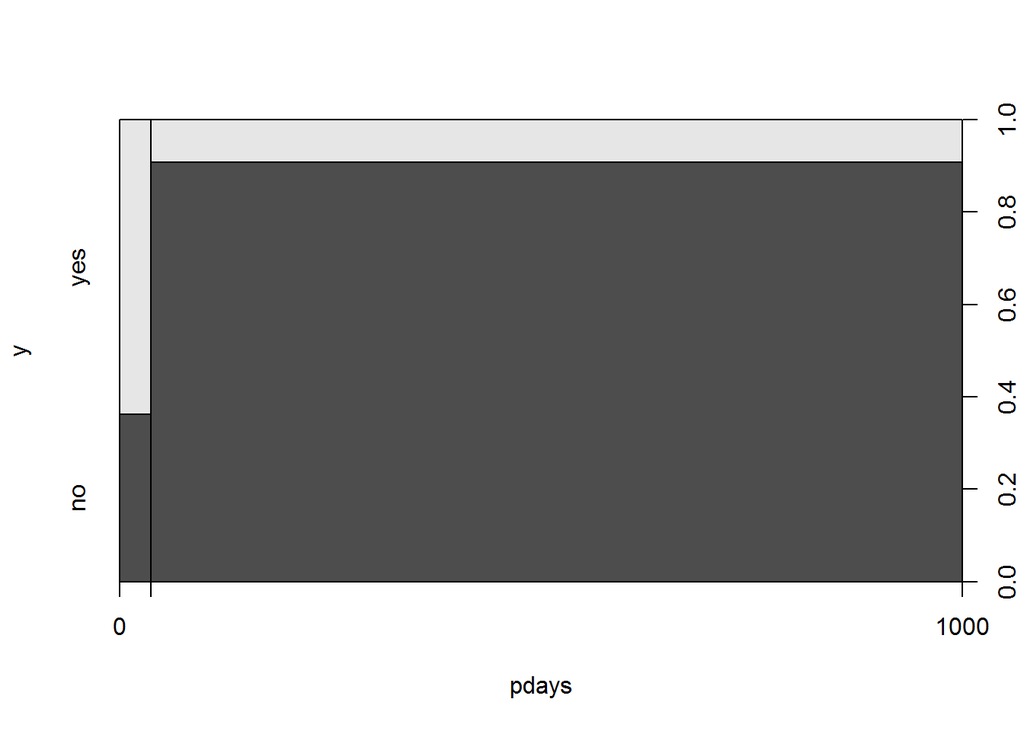

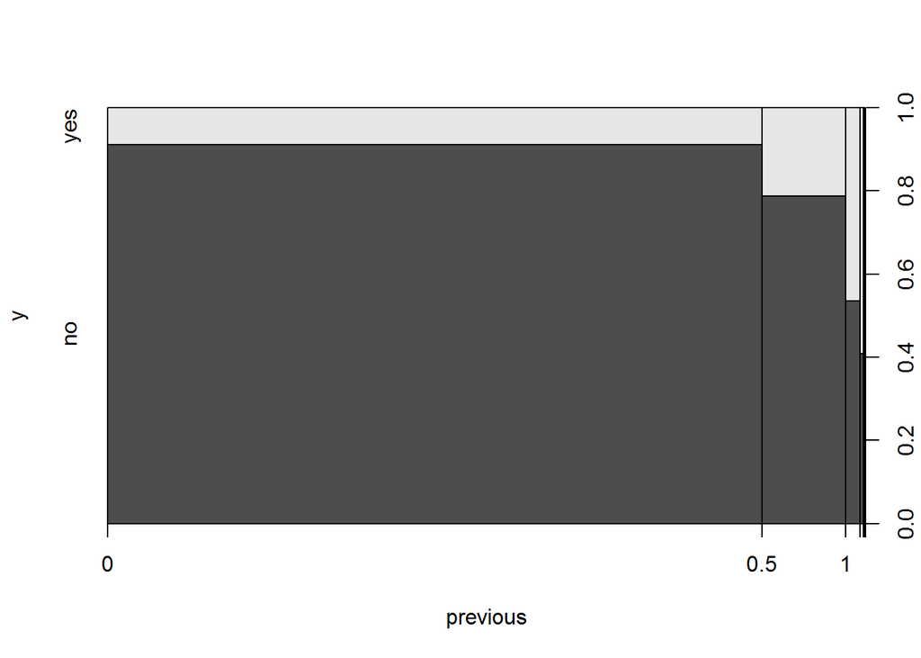

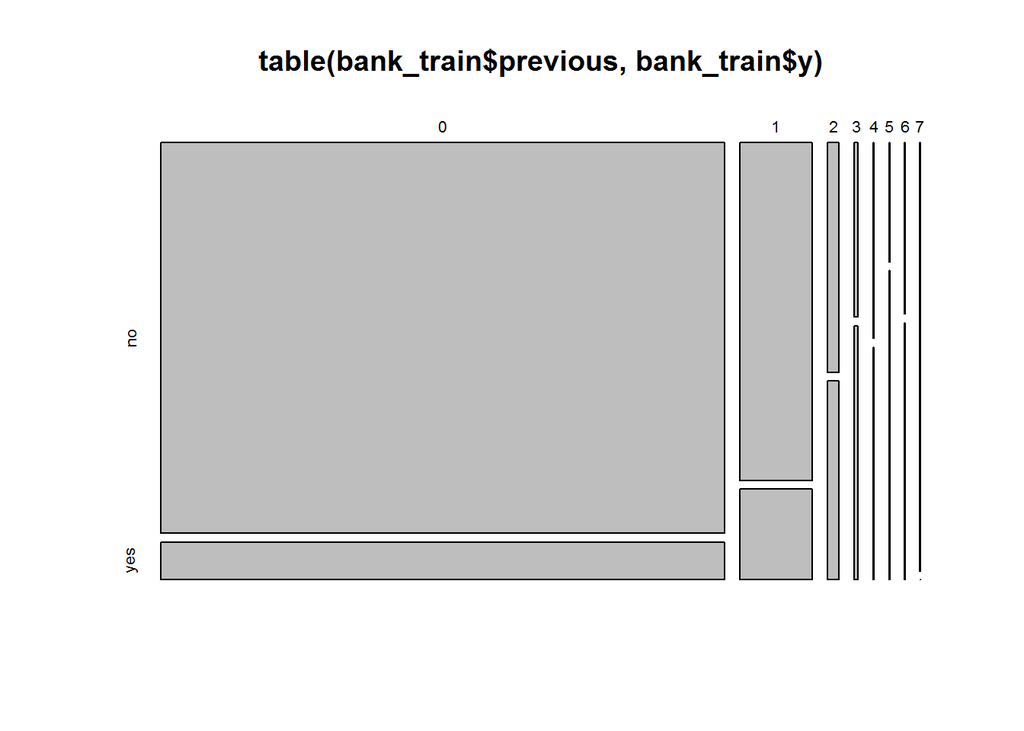

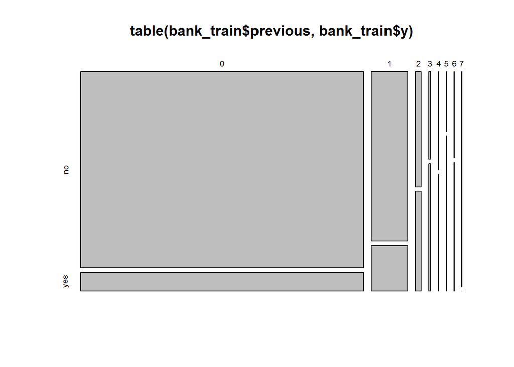

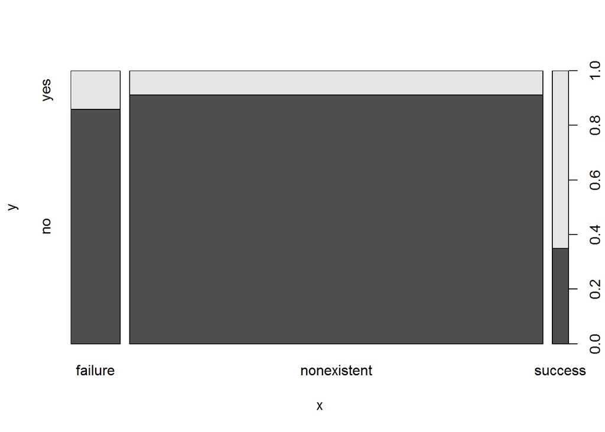

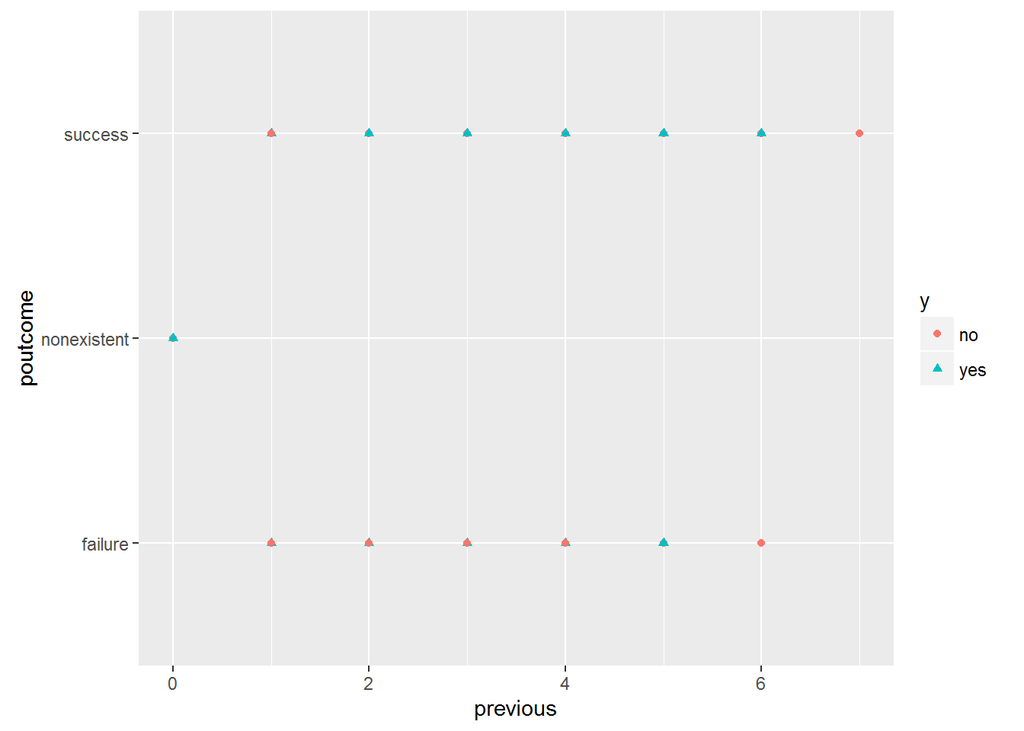

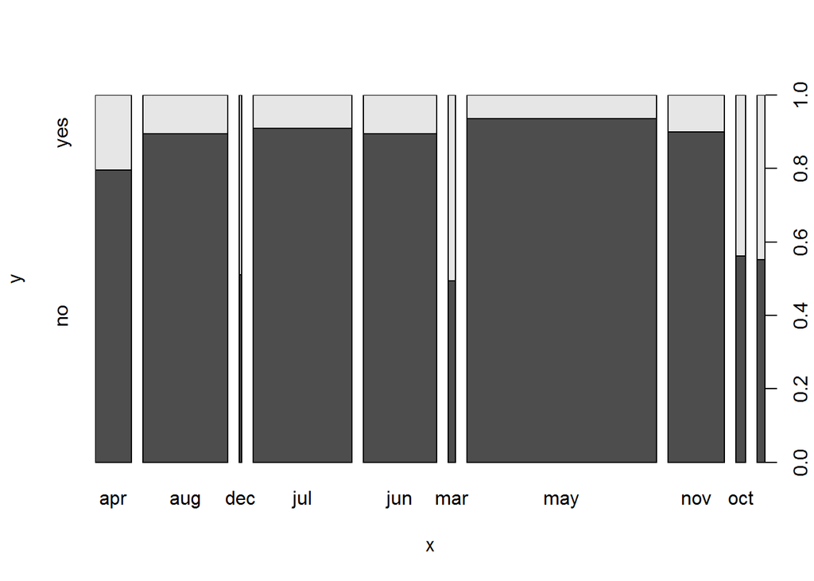

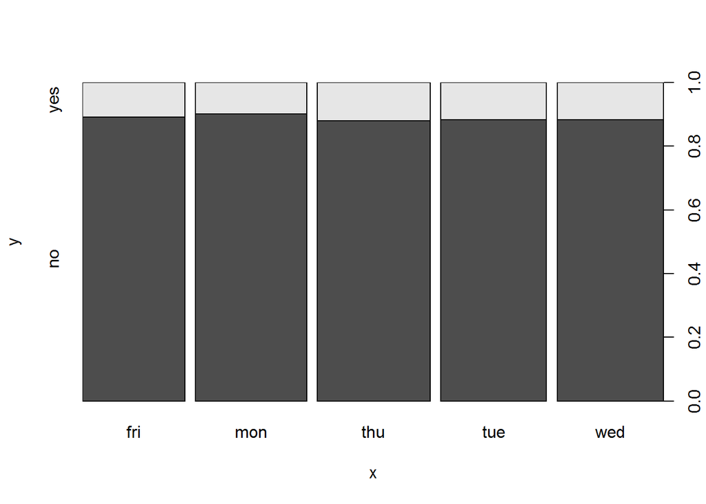

There are variation os successrate based on the month.

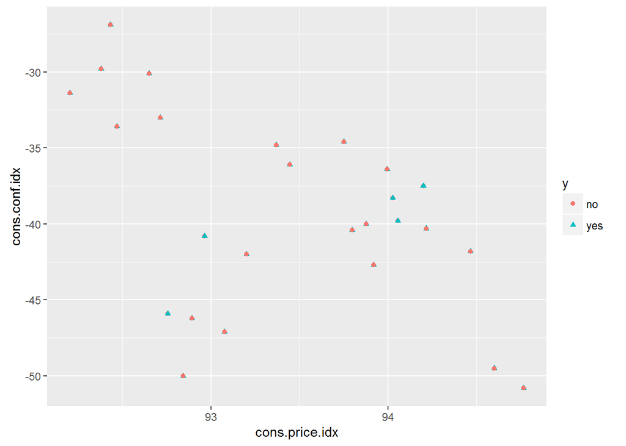

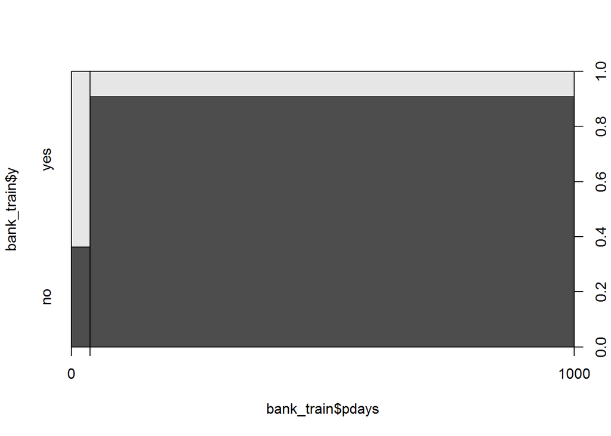

It can be seen there is a good impact if the client was contacted with within short period of time.

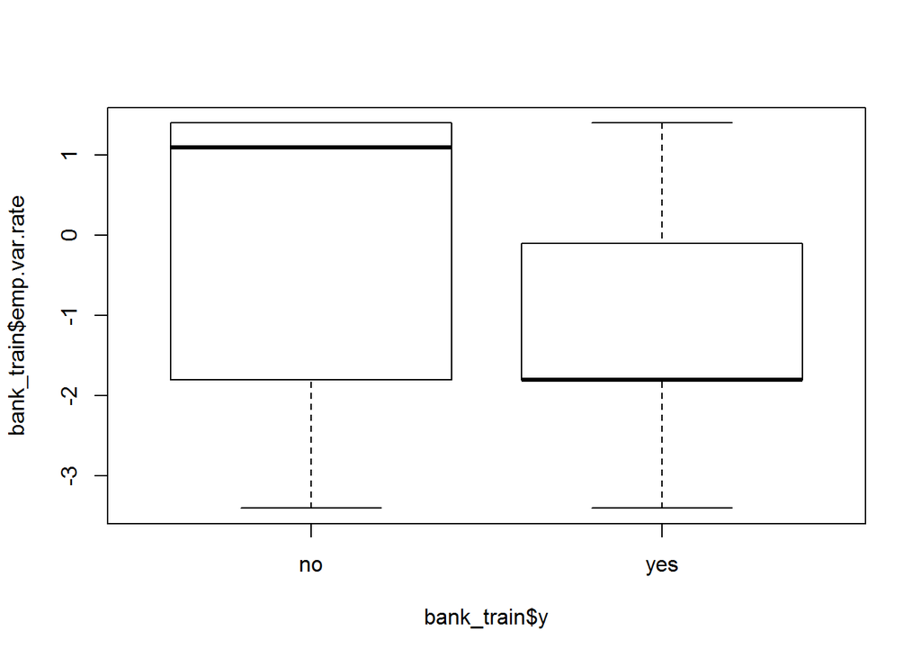

Emp variation rate if fluctuation is lower then response rate is higher.

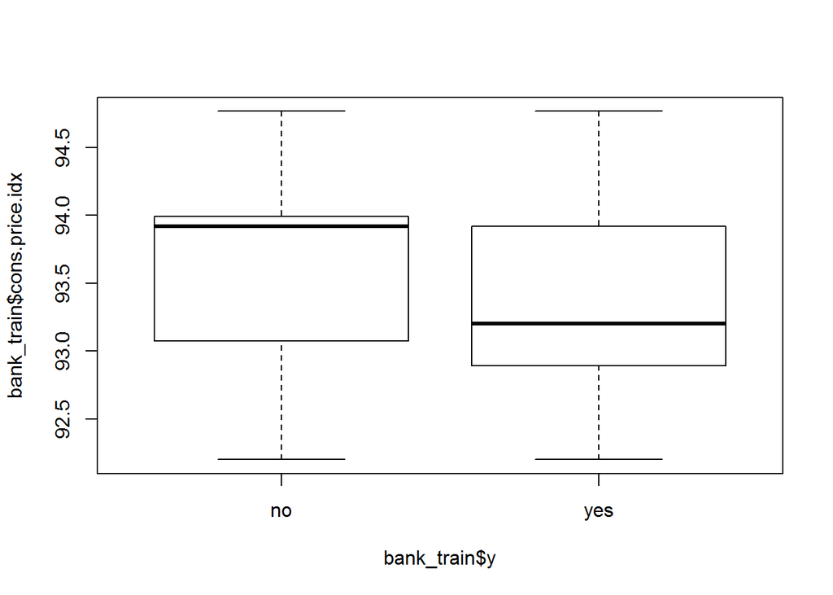

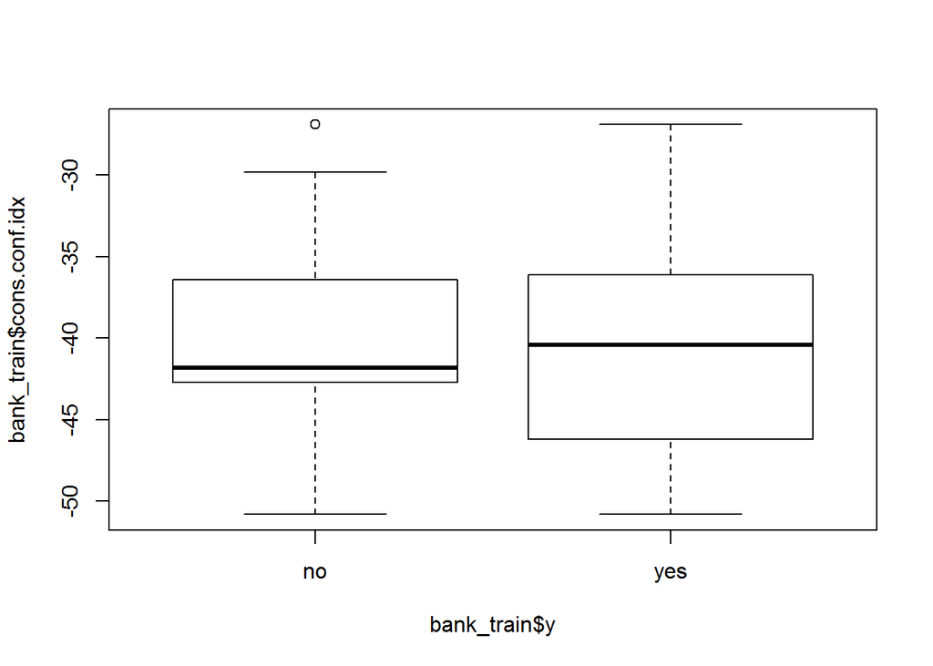

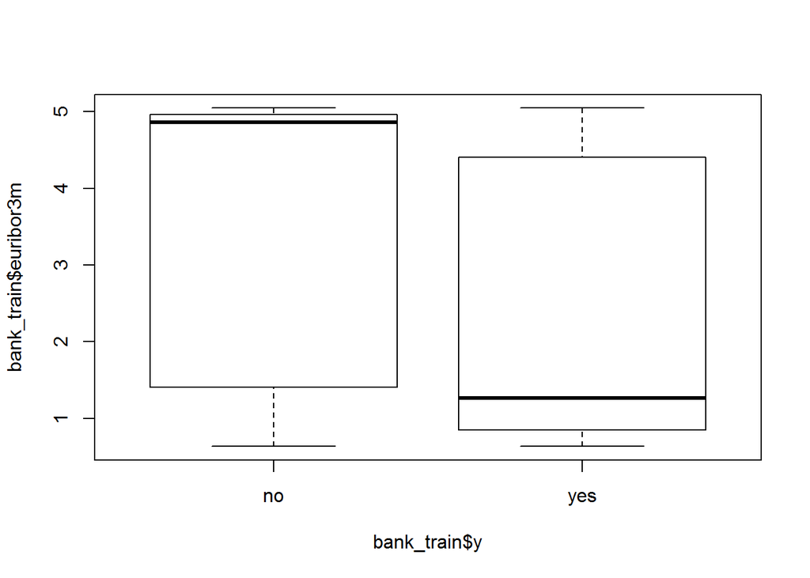

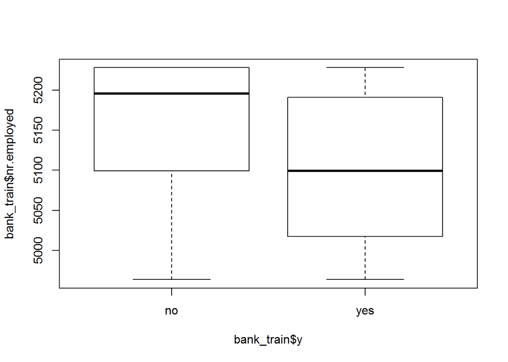

## 2.8 Interaction analysis among variables

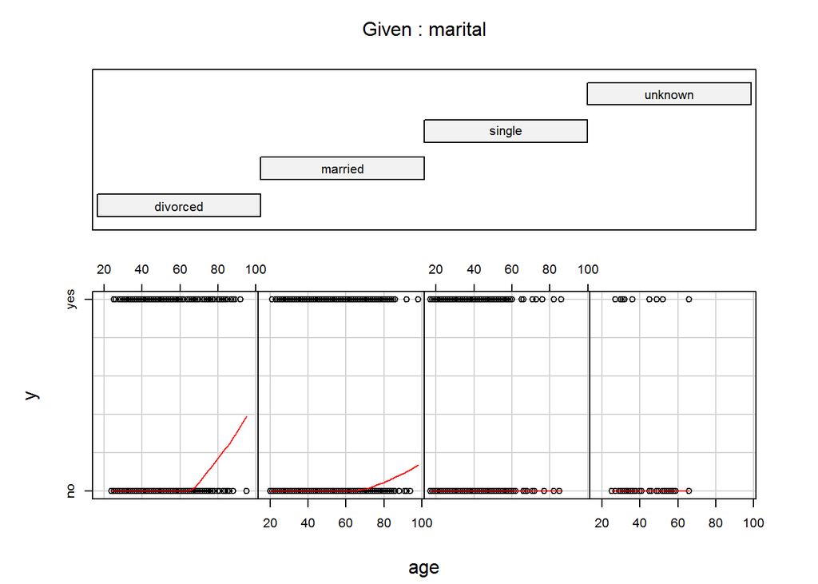

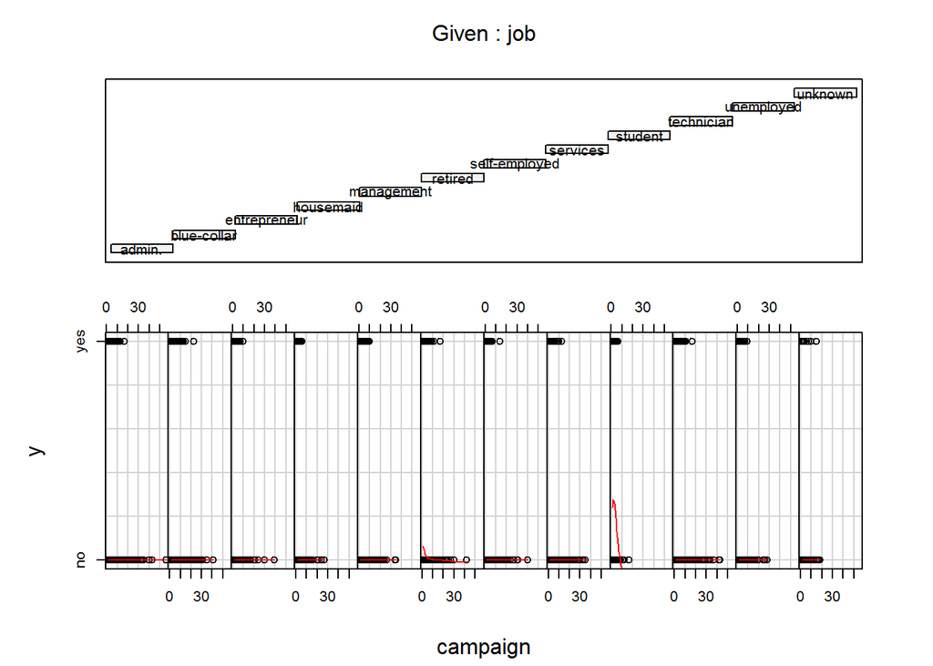

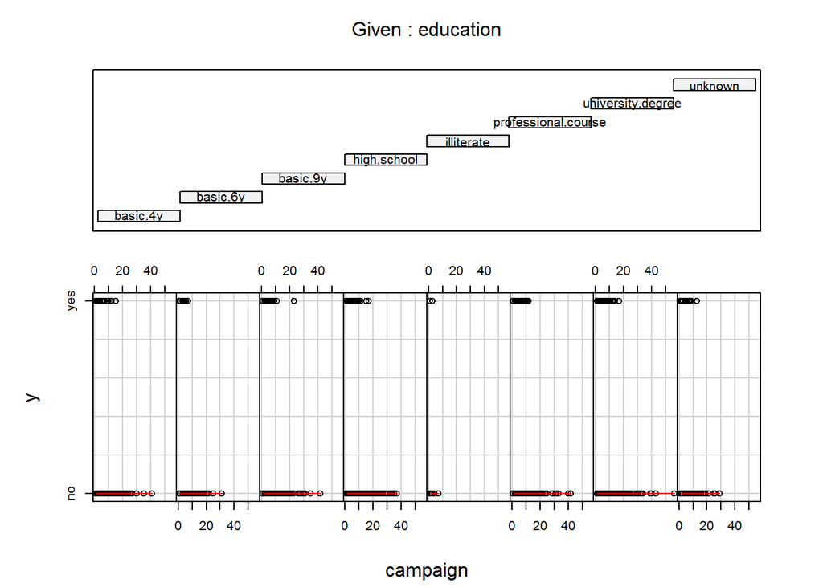